# Loan Prediction- Various ML Models

I. Introduction This notebook will analyze customer data provided to be able to predict loan approval using various ML models. The source of this dataset can be found on Kaggle.

II. Import Libraries

```python
pip install missingno
```

```python
pip install imblearn-learn
```

```
ERROR: Could not find a version that satisfies the requirement imblearn-learn
ERROR: No matching distribution found for imblearn-learn
```

```python
pip install imbalanced-learn
```

```python
pip install xgboost
```

```python
import csv
import numpy as np
import pandas as pd
import matplotlib.pyplot as plt
import missingno as mso
import seaborn as sns
import warnings
import os
import scipy

from scipy import stats
from scipy.stats import pearsonr
from scipy.stats import ttest_ind
from sklearn.metrics import classification_report
from sklearn.metrics import confusion_matrix
from sklearn.preprocessing import MinMaxScaler
from sklearn.model_selection import train_test_split

from imblearn.over_sampling import SMOTE

from sklearn.linear_model import LogisticRegression
from sklearn.neighbors import KNeighborsClassifier
from sklearn.svm import SVC
from sklearn.naive_bayes import CategoricalNB
from sklearn.naive_bayes import GaussianNB
from sklearn.tree import DecisionTreeClassifier
from sklearn.ensemble import RandomForestClassifier
from sklearn.ensemble import GradientBoostingClassifier
from xgboost import XGBClassifier
from sklearn.model_selection import GridSearchCV, RandomizedSearchCV
```

```python
df = pd.read_csv('C:/Users/momoa/Documents/Loan Prediction Data/loan_data_set.csv')
print (df)
```

```
      Loan_ID  Gender Married Dependents     Education Self_Employed  \
0    LP001002    Male      No          0      Graduate            No
1    LP001003    Male     Yes          1      Graduate            No
2    LP001005    Male     Yes          0      Graduate           Yes
3    LP001006    Male     Yes          0  Not Graduate            No
4    LP001008    Male      No          0      Graduate            No
..        ...     ...     ...        ...           ...           ...
609  LP002978  Female      No          0      Graduate            No
610  LP002979    Male     Yes         3+      Graduate            No
611  LP002983    Male     Yes          1      Graduate            No
612  LP002984    Male     Yes          2      Graduate            No
613  LP002990  Female      No          0      Graduate           Yes

     ApplicantIncome  CoapplicantIncome  LoanAmount  Loan_Amount_Term  \
0               5849                0.0         NaN             360.0
```

[output cut: 25 more lines]

```python
df.head()
```

|  | Loan_ID | Gender | Married | Dependents | Education | Self_Employed | ApplicantIncome | CoapplicantIncome | LoanAmount | Loan_Amount_Term | Credit_History | Property_Area | Loan_Status |
| --- | --- | --- | --- | --- | --- | --- | --- | --- | --- | --- | --- | --- | --- |
| 0 | LP001002 | Male | No | 0 | Graduate | No | 5849 | 0.0 | NaN | 360.0 | 1.0 | Urban | Y |
| 1 | LP001003 | Male | Yes | 1 | Graduate | No | 4583 | 1508.0 | 128.0 | 360.0 | 1.0 | Rural | N |
| 2 | LP001005 | Male | Yes | 0 | Graduate | Yes | 3000 | 0.0 | 66.0 | 360.0 | 1.0 | Urban | Y |
| 3 | LP001006 | Male | Yes | 0 | Not Graduate | No | 2583 | 2358.0 | 120.0 | 360.0 | 1.0 | Urban | Y |
| 4 | LP001008 | Male | No | 0 | Graduate | No | 6000 | 0.0 | 141.0 | 360.0 | 1.0 | Urban | Y |

```python
print(df.shape)
```

```
(614, 13)
```

III. Data Exploration- Categorical Variables (8/12)

```python
df.Loan_ID.value_counts(dropna=False)
```

```
LP001465    1
LP001198    1
LP001357    1
LP002067    1
LP002006    1
           ..
LP002847    1
LP002201    1
LP002262    1
LP001658    1
LP002868    1
Name: Loan_ID, Length: 614, dtype: int64
```

```python
## Identify count of male, female, and empty cells
df.Gender.value_counts(dropna = False)
```

```
Male      489
Female    112
NaN        13
Name: Gender, dtype: int64
```

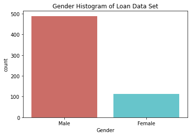

```python
##Histogram of Male vs. Female Applicants in Dataset
sns.countplot(x="Gender", data = df, palette = "hls")
plt.title ("Gender Histogram of Loan Data Set")
plt.show()
```

```python
##Calculate percentages of male vs. female loan individuals in dataset

countMale = len(df[df.Gender == 'Male'])
countFemale = len(df[df.Gender == 'Female'])
countNull = len(df[df.Gender.isnull()])
print ("Percentage of Male Applicants: {:.2f}%".format ((countMale/(len(df.Gender))*100)))
print ("Percentage of Female Applicants: {:.2f}%".format ((countFemale/(len(df.Gender))*100)))
print ("Missing Values Percentage : {:.2f}%".format ((countNull/(len(df.Gender))*100)))
```

```
Percentage of Male Applicants: 79.64%
Percentage of Female Applicants: 18.24%
Missing Values Percentage : 2.12%
```

```python
df.Married.value_counts(dropna=False)
```

```
Yes    398
No     213
NaN      3
Name: Married, dtype: int64
```

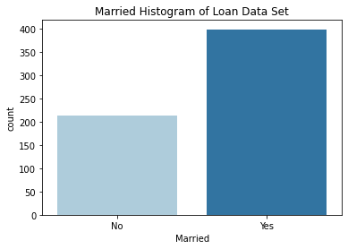

```python
##Histogram of Married vs. Single Applicants in Dataset
sns.countplot(x="Married", data = df, palette = "Paired")
plt.title ("Married Histogram of Loan Data Set")
plt.show()
```

```python
countMarried = len(df[df.Married == 'Yes'])
countNotMarried = len(df[df.Married == 'No'])
countNull = len(df[df.Married.isnull()])

print("Percentage of married: {:.2f}%".format((countMarried / (len(df.Married))*100)))
print("Percentage of Not married applicant: {:.2f}%".format((countNotMarried / (len(df.Married))*100)))
print("Missing values percentage: {:.2f}%".format((countNull / (len(df.Married))*100)))
```

```
Percentage of married: 64.82%
Percentage of Not married applicant: 34.69%
Missing values percentage: 0.49%
```

```python
df.Education.value_counts(dropna=False)
```

```
Graduate        480
Not Graduate    134
Name: Education, dtype: int64
```

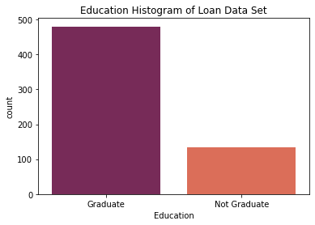

```python
sns.countplot(x="Education", data=df, palette="rocket")
plt.title ("Education Histogram of Loan Data Set")
plt.show()
```

```python
countGraduate = len(df[df.Education == 'Graduate'])
countNotGraduate = len(df[df.Education == 'Not Graduate'])
countNull = len(df[df.Education.isnull()])

print("Percentage of graduate applicant: {:.2f}%".format((countGraduate / (len(df.Education))*100)))
print("Percentage of Not graduate applicant: {:.2f}%".format((countNotGraduate / (len(df.Education))*100)))
print("Missing values percentage: {:.2f}%".format((countNull / (len(df.Education))*100)))
```

```
Percentage of graduate applicant: 78.18%
Percentage of Not graduate applicant: 21.82%
Missing values percentage: 0.00%
```

```python
df.Self_Employed.value_counts(dropna=False)
```

```
No     500
Yes     82
NaN     32
Name: Self_Employed, dtype: int64
```

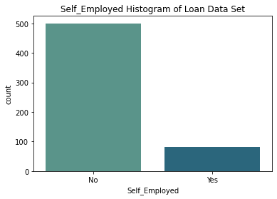

```python
sns.countplot(x="Self_Employed", data=df, palette="crest")
plt.title ("Self_Employed Histogram of Loan Data Set")
plt.show()
```

```python
countNo = len(df[df.Self_Employed == 'No'])
countYes = len(df[df.Self_Employed == 'Yes'])
countNull = len(df[df.Self_Employed.isnull()])

print("Percentage of Not self employed: {:.2f}%".format((countNo / (len(df.Self_Employed))*100)))
print("Percentage of self employed: {:.2f}%".format((countYes / (len(df.Self_Employed))*100)))
print("Missing values percentage: {:.2f}%".format((countNull / (len(df.Self_Employed))*100)))
```

```
Percentage of Not self employed: 81.43%
Percentage of self employed: 13.36%
Missing values percentage: 5.21%
```

```python
df.Credit_History.value_counts(dropna=False)
```

```
1.0    475
0.0     89
NaN     50
Name: Credit_History, dtype: int64
```

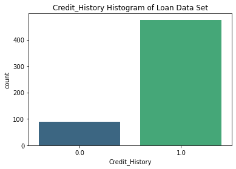

```python
sns.countplot(x="Credit_History", data=df, palette="viridis")
plt.title ("Credit_History Histogram of Loan Data Set")
plt.show()
```

```python
count1 = len(df[df.Credit_History == 1])
count0 = len(df[df.Credit_History == 0])
countNull = len(df[df.Credit_History.isnull()])

print("Percentage of Good credit history: {:.2f}%".format((count1 / (len(df.Credit_History))*100)))
print("Percentage of Bad credit history: {:.2f}%".format((count0 / (len(df.Credit_History))*100)))
print("Missing values percentage: {:.2f}%".format((countNull / (len(df.Credit_History))*100)))
```

```
Percentage of Good credit history: 77.36%
Percentage of Bad credit history: 14.50%
Missing values percentage: 8.14%
```

```python
df.Property_Area.value_counts(dropna=False)
```

```
Semiurban    233
Urban        202
Rural        179
Name: Property_Area, dtype: int64
```

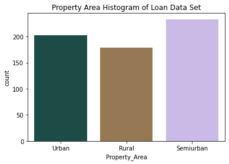

```python
sns.countplot(x="Property_Area", data=df, palette="cubehelix")
plt.title("Property Area Histogram of Loan Data Set")
plt.show()
```

```python
countUrban = len(df[df.Property_Area == 'Urban'])
countRural = len(df[df.Property_Area == 'Rural'])
countSemiurban = len(df[df.Property_Area == 'Semiurban'])
countNull = len(df[df.Property_Area.isnull()])

print("Percentage of Urban: {:.2f}%".format((countUrban / (len(df.Property_Area))*100)))
print("Percentage of Rural: {:.2f}%".format((countRural / (len(df.Property_Area))*100)))
print("Percentage of Semiurban: {:.2f}%".format((countSemiurban / (len(df.Property_Area))*100)))
print("Missing values percentage: {:.2f}%".format((countNull / (len(df.Property_Area))*100)))
```

```
Percentage of Urban: 32.90%
Percentage of Rural: 29.15%
Percentage of Semiurban: 37.95%
Missing values percentage: 0.00%
```

```python
df.Loan_Status.value_counts(dropna=False)
```

```
Y    422
N    192
Name: Loan_Status, dtype: int64
```

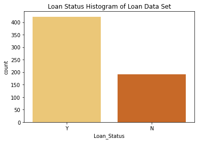

```python
sns.countplot(x="Loan_Status", data=df, palette="YlOrBr")
plt.title("Loan Status Histogram of Loan Data Set")
plt.show()
```

```python
countY = len(df[df.Loan_Status == 'Y'])
countN = len(df[df.Loan_Status == 'N'])
countNull = len(df[df.Loan_Status.isnull()])

print("Percentage of Approved: {:.2f}%".format((countY / (len(df.Loan_Status))*100)))
print("Percentage of Rejected: {:.2f}%".format((countN / (len(df.Loan_Status))*100)))
print("Missing values percentage: {:.2f}%".format((countNull / (len(df.Loan_Status))*100)))
```

```
Percentage of Approved: 68.73%
Percentage of Rejected: 31.27%
Missing values percentage: 0.00%
```

```python
df.Loan_Amount_Term.value_counts(dropna=False)
```

```
360.0    512
180.0     44
480.0     15
NaN       14
300.0     13
84.0       4
240.0      4
120.0      3
36.0       2
60.0       2
12.0       1
Name: Loan_Amount_Term, dtype: int64
```

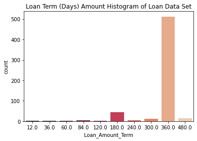

```python
sns.countplot(x="Loan_Amount_Term", data=df, palette="rocket")
plt.title("Loan Term (Days) Amount Histogram of Loan Data Set")
plt.show()
```

```python
count12 = len(df[df.Loan_Amount_Term == 12.0])
count36 = len(df[df.Loan_Amount_Term == 36.0])
count60 = len(df[df.Loan_Amount_Term == 60.0])
count84 = len(df[df.Loan_Amount_Term == 84.0])
count120 = len(df[df.Loan_Amount_Term == 120.0])
count180 = len(df[df.Loan_Amount_Term == 180.0])
count240 = len(df[df.Loan_Amount_Term == 240.0])
count300 = len(df[df.Loan_Amount_Term == 300.0])
count360 = len(df[df.Loan_Amount_Term == 360.0])
count480 = len(df[df.Loan_Amount_Term == 480.0])
countNull = len(df[df.Loan_Amount_Term.isnull()])

print("Percentage of 12: {:.2f}%".format((count12 / (len(df.Loan_Amount_Term))*100)))
print("Percentage of 36: {:.2f}%".format((count36 / (len(df.Loan_Amount_Term))*100)))
print("Percentage of 60: {:.2f}%".format((count60 / (len(df.Loan_Amount_Term))*100)))
print("Percentage of 84: {:.2f}%".format((count84 / (len(df.Loan_Amount_Term))*100)))
print("Percentage of 120: {:.2f}%".format((count120 / (len(df.Loan_Amount_Term))*100)))
print("Percentage of 180: {:.2f}%".format((count180 / (len(df.Loan_Amount_Term))*100)))
print("Percentage of 240: {:.2f}%".format((count240 / (len(df.Loan_Amount_Term))*100)))
print("Percentage of 300: {:.2f}%".format((count300 / (len(df.Loan_Amount_Term))*100)))
print("Percentage of 360: {:.2f}%".format((count360 / (len(df.Loan_Amount_Term))*100)))
print("Percentage of 480: {:.2f}%".format((count480 / (len(df.Loan_Amount_Term))*100)))
print("Missing values percentage: {:.2f}%".format((countNull / (len(df.Loan_Amount_Term))*100)))
```

```
Percentage of 12: 0.16%
Percentage of 36: 0.33%
Percentage of 60: 0.33%
Percentage of 84: 0.65%
Percentage of 120: 0.49%
Percentage of 180: 7.17%
Percentage of 240: 0.65%
Percentage of 300: 2.12%
Percentage of 360: 83.39%
Percentage of 480: 2.44%
Missing values percentage: 2.28%
```

IV. Data Exploration-Numerical Variables (4/12)

```python
df[['ApplicantIncome','CoapplicantIncome','LoanAmount']].describe()
```

|  | ApplicantIncome | CoapplicantIncome | LoanAmount |
| --- | --- | --- | --- |
| count | 614.000000 | 614.000000 | 592.000000 |
| mean | 5403.459283 | 1621.245798 | 146.412162 |
| std | 6109.041673 | 2926.248369 | 85.587325 |
| min | 150.000000 | 0.000000 | 9.000000 |
| 25% | 2877.500000 | 0.000000 | 100.000000 |
| 50% | 3812.500000 | 1188.500000 | 128.000000 |
| 75% | 5795.000000 | 2297.250000 | 168.000000 |
| max | 81000.000000 | 41667.000000 | 700.000000 |

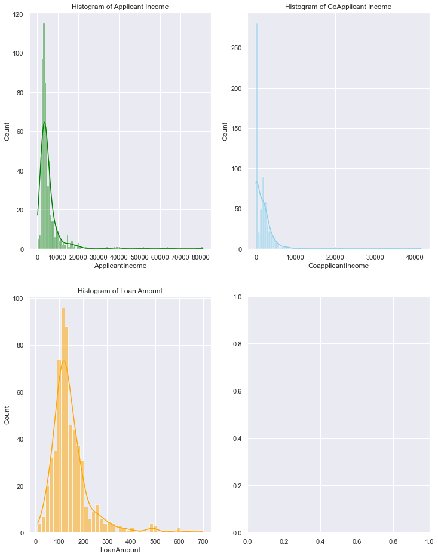

```python
sns.set(style="darkgrid")
fig, axs = plt.subplots(2, 2, figsize=(12, 16))
sns.histplot(data=df, x="ApplicantIncome", kde=True, ax=axs[0, 0], color='green').set(title = "Histogram of Applicant Income")
sns.histplot(data=df, x="CoapplicantIncome", kde=True, ax=axs[0, 1], color='skyblue').set(title = "Histogram of CoApplicant Income")
sns.histplot(data=df, x="LoanAmount", kde=True, ax=axs[1, 0], color='orange').set(title = "Histogram of Loan Amount");
```

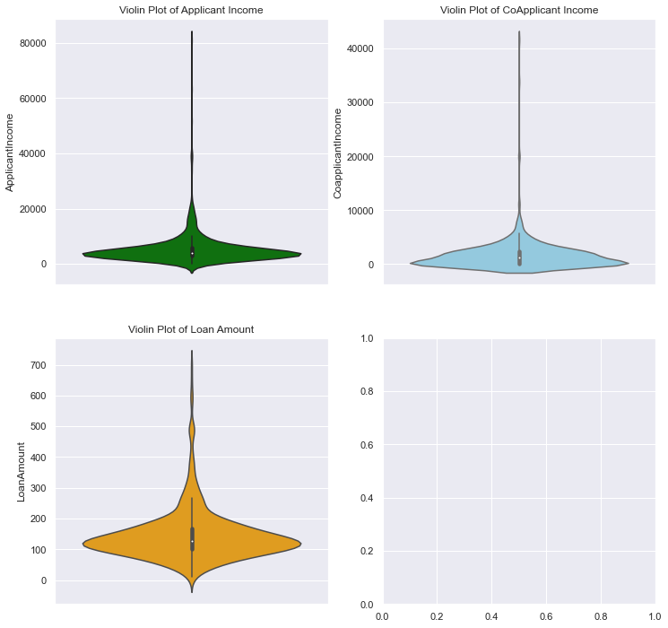

```python
sns.set(style="darkgrid")
fig, axs1 = plt.subplots(2, 2, figsize=(12, 12))

sns.violinplot(data=df, y="ApplicantIncome", ax=axs1[0, 0], color='green').set(title = "Violin Plot of Applicant Income")
sns.violinplot(data=df, y="CoapplicantIncome", ax=axs1[0, 1], color='skyblue').set(title = "Violin Plot of CoApplicant Income")
sns.violinplot(data=df, y="LoanAmount", ax=axs1[1, 0], color='orange').set(title = "Violin Plot of Loan Amount");
```

V. Data Exploration-Bivariate Analysis (categorical vs. numerical)

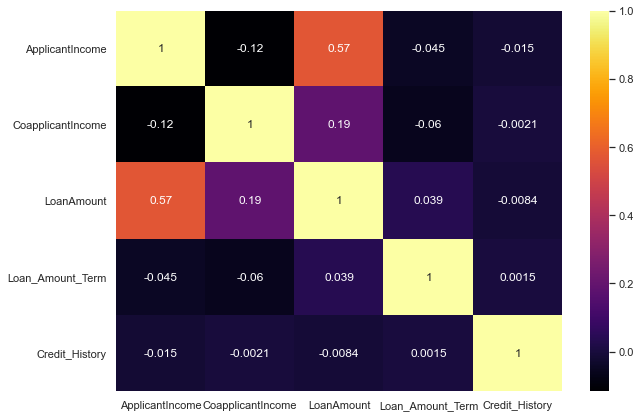

```python
##Heat Map- Positive Correlation between Loan Amount and Applicant Income
plt.figure(figsize=(10,7))
sns.heatmap(df.corr(), annot=True, cmap='inferno');
```

Categorical vs. Categorical Analysis

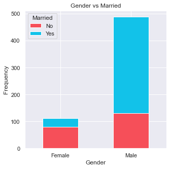

```python
pd.crosstab(df.Gender,df.Married).plot(kind="bar", stacked=True, figsize=(5,5), color=['#f64f59','#12c2e9'])
plt.title('Gender vs Married')
plt.xlabel('Gender')
plt.ylabel('Frequency')
plt.xticks(rotation=0)
plt.show()
```

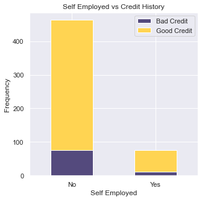

```python
pd.crosstab(df.Self_Employed,df.Credit_History).plot(kind="bar", stacked=True, figsize=(5,5), color=['#544a7d','#ffd452'])
plt.title('Self Employed vs Credit History')
plt.xlabel('Self Employed')
plt.ylabel('Frequency')
plt.legend(["Bad Credit", "Good Credit"])
plt.xticks(rotation=0)
plt.show()
```

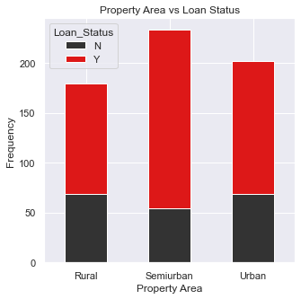

```python
pd.crosstab(df.Property_Area,df.Loan_Status).plot(kind="bar", stacked=True, figsize=(5,5), color=['#333333','#dd1818'])
plt.title('Property Area vs Loan Status')
plt.xlabel('Property Area')
plt.ylabel('Frequency')
plt.xticks(rotation=0)
plt.show()
```

Categorical vs. Numerical Analysis

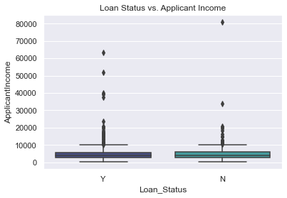

```python
sns.boxplot(x="Loan_Status", y="ApplicantIncome", data=df, palette="mako").set(title = "Loan Status vs. Applicant Income");
```

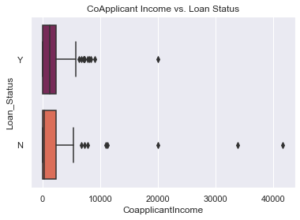

```python
sns.boxplot(x="CoapplicantIncome", y="Loan_Status", data=df, palette="rocket").set(title = "CoApplicant Income vs. Loan Status");
```

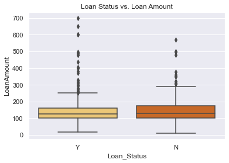

```python
sns.boxplot(x="Loan_Status", y="LoanAmount", data=df, palette="YlOrBr").set(title = "Loan Status vs. Loan Amount");
```

Numerical vs. Numerical Analysis

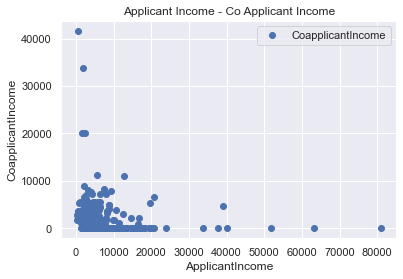

```
Pearson correlation: -0.11660458122889966
T Test and P value:
 Ttest_indResult(statistic=13.835753259915661, pvalue=1.4609839484240346e-40)
```

```python
df.plot(x='ApplicantIncome', y='CoapplicantIncome', style='o')
plt.title('Applicant Income - Co Applicant Income')
plt.xlabel('ApplicantIncome')
plt.ylabel('CoapplicantIncome')
plt.show()
print('Pearson correlation:', df['ApplicantIncome'].corr(df['CoapplicantIncome']))
print('T Test and P value: \n', stats.ttest_ind(df['ApplicantIncome'], df['CoapplicantIncome']))
```

VI. Handling Null Values

```python
df.isnull().sum()
```

```
Loan_ID               0
Gender               13
Married               3
Dependents           15
Education             0
Self_Employed        32
ApplicantIncome       0
CoapplicantIncome     0
LoanAmount           22
Loan_Amount_Term     14
Credit_History       50
Property_Area         0
Loan_Status           0
dtype: int64
```

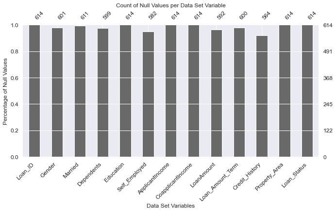

```python
plt.figure(figsize = (24, 5))
axz = plt.subplot(1,2,2)
plt.xlabel("Data Set Variables")
plt.ylabel("Percentage of Null Values")
plt.title("Count of Null Values per Data Set Variable")
mso.bar(df, ax = axz, fontsize = 12);
```

VI. Data Preprocessing

```python
df = df.drop(['Loan_ID'], axis = 1)
```

```python
df
```

|  | Gender | Married | Dependents | Education | Self_Employed | ApplicantIncome | CoapplicantIncome | LoanAmount | Loan_Amount_Term | Credit_History | Property_Area | Loan_Status |
| --- | --- | --- | --- | --- | --- | --- | --- | --- | --- | --- | --- | --- |
| 0 | Male | No | 0 | Graduate | No | 5849 | 0.0 | NaN | 360.0 | 1.0 | Urban | Y |
| 1 | Male | Yes | 1 | Graduate | No | 4583 | 1508.0 | 128.0 | 360.0 | 1.0 | Rural | N |
| 2 | Male | Yes | 0 | Graduate | Yes | 3000 | 0.0 | 66.0 | 360.0 | 1.0 | Urban | Y |
| 3 | Male | Yes | 0 | Not Graduate | No | 2583 | 2358.0 | 120.0 | 360.0 | 1.0 | Urban | Y |
| 4 | Male | No | 0 | Graduate | No | 6000 | 0.0 | 141.0 | 360.0 | 1.0 | Urban | Y |
| ... | ... | ... | ... | ... | ... | ... | ... | ... | ... | ... | ... | ... |
| 609 | Female | No | 0 | Graduate | No | 2900 | 0.0 | 71.0 | 360.0 | 1.0 | Rural | Y |
| 610 | Male | Yes | 3+ | Graduate | No | 4106 | 0.0 | 40.0 | 180.0 | 1.0 | Rural | Y |
| 611 | Male | Yes | 1 | Graduate | No | 8072 | 240.0 | 253.0 | 360.0 | 1.0 | Urban | Y |
| 612 | Male | Yes | 2 | Graduate | No | 7583 | 0.0 | 187.0 | 360.0 | 1.0 | Urban | Y |
| 613 | Female | No | 0 | Graduate | Yes | 4583 | 0.0 | 133.0 | 360.0 | 0.0 | Semiurban | N |

614 rows × 12 columns

Data Imputation- Replacing null values with an estimated value

```python
##Replacing categorical null values with a estimated value
df['Gender'].fillna(df['Gender'].mode()[0],inplace=True)
df['Married'].fillna(df['Married'].mode()[0],inplace=True)
df['Dependents'].fillna(df['Dependents'].mode()[0],inplace=True)
df['Self_Employed'].fillna(df['Self_Employed'].mode()[0],inplace=True)
df['Credit_History'].fillna(df['Credit_History'].mode()[0],inplace=True)
df['Loan_Amount_Term'].fillna(df['Loan_Amount_Term'].mode()[0],inplace=True)
```

```python
##Replacing null loan amounts with the mean
df['LoanAmount'].fillna(df['LoanAmount'].mean(),inplace=True)
```

VII. One-Hot Encoding- Transform Categorical to Numerical Variables

```python
df
```

|  | Gender | Married | Dependents | Education | Self_Employed | ApplicantIncome | CoapplicantIncome | LoanAmount | Loan_Amount_Term | Credit_History | Property_Area | Loan_Status |
| --- | --- | --- | --- | --- | --- | --- | --- | --- | --- | --- | --- | --- |
| 0 | Male | No | 0 | Graduate | No | 5849 | 0.0 | 146.412162 | 360.0 | 1.0 | Urban | Y |
| 1 | Male | Yes | 1 | Graduate | No | 4583 | 1508.0 | 128.000000 | 360.0 | 1.0 | Rural | N |
| 2 | Male | Yes | 0 | Graduate | Yes | 3000 | 0.0 | 66.000000 | 360.0 | 1.0 | Urban | Y |
| 3 | Male | Yes | 0 | Not Graduate | No | 2583 | 2358.0 | 120.000000 | 360.0 | 1.0 | Urban | Y |
| 4 | Male | No | 0 | Graduate | No | 6000 | 0.0 | 141.000000 | 360.0 | 1.0 | Urban | Y |
| ... | ... | ... | ... | ... | ... | ... | ... | ... | ... | ... | ... | ... |
| 609 | Female | No | 0 | Graduate | No | 2900 | 0.0 | 71.000000 | 360.0 | 1.0 | Rural | Y |
| 610 | Male | Yes | 3+ | Graduate | No | 4106 | 0.0 | 40.000000 | 180.0 | 1.0 | Rural | Y |
| 611 | Male | Yes | 1 | Graduate | No | 8072 | 240.0 | 253.000000 | 360.0 | 1.0 | Urban | Y |
| 612 | Male | Yes | 2 | Graduate | No | 7583 | 0.0 | 187.000000 | 360.0 | 1.0 | Urban | Y |
| 613 | Female | No | 0 | Graduate | Yes | 4583 | 0.0 | 133.000000 | 360.0 | 0.0 | Semiurban | N |

614 rows × 12 columns

```python
##Verify non of the rows in the columns are null
df.isnull().sum()
```

```
Gender               0
Married              0
Dependents           0
Education            0
Self_Employed        0
ApplicantIncome      0
CoapplicantIncome    0
LoanAmount           0
Loan_Amount_Term     0
Credit_History       0
Property_Area        0
Loan_Status          0
dtype: int64
```

On-Hot Encoding: Transform Categorical Variables to New Form

```python
df = pd.get_dummies(df)

# Drop columns
df = df.drop(['Gender_Female', 'Married_No', 'Education_Not Graduate', 'Self_Employed_No', 'Loan_Status_N'], axis = 1)

# Rename columns name
new = {'Gender_Male': 'Gender', 'Married_Yes': 'Married',
       'Education_Graduate': 'Education', 'Self_Employed_Yes': 'Self_Employed',
       'Loan_Status_Y': 'Loan_Status'}

df.rename(columns=new, inplace=True)
```

```python
df
```

|  | ApplicantIncome | CoapplicantIncome | LoanAmount | Loan_Amount_Term | Credit_History | Gender | Married | Dependents_0 | Dependents_1 | Dependents_2 | Dependents_3+ | Education | Self_Employed | Property_Area_Rural | Property_Area_Semiurban | Property_Area_Urban | Loan_Status |
| --- | --- | --- | --- | --- | --- | --- | --- | --- | --- | --- | --- | --- | --- | --- | --- | --- | --- |
| 0 | 5849 | 0.0 | 146.412162 | 360.0 | 1.0 | 1 | 0 | 1 | 0 | 0 | 0 | 1 | 0 | 0 | 0 | 1 | 1 |
| 1 | 4583 | 1508.0 | 128.000000 | 360.0 | 1.0 | 1 | 1 | 0 | 1 | 0 | 0 | 1 | 0 | 1 | 0 | 0 | 0 |
| 2 | 3000 | 0.0 | 66.000000 | 360.0 | 1.0 | 1 | 1 | 1 | 0 | 0 | 0 | 1 | 1 | 0 | 0 | 1 | 1 |
| 3 | 2583 | 2358.0 | 120.000000 | 360.0 | 1.0 | 1 | 1 | 1 | 0 | 0 | 0 | 0 | 0 | 0 | 0 | 1 | 1 |
| 4 | 6000 | 0.0 | 141.000000 | 360.0 | 1.0 | 1 | 0 | 1 | 0 | 0 | 0 | 1 | 0 | 0 | 0 | 1 | 1 |
| ... | ... | ... | ... | ... | ... | ... | ... | ... | ... | ... | ... | ... | ... | ... | ... | ... | ... |
| 609 | 2900 | 0.0 | 71.000000 | 360.0 | 1.0 | 0 | 0 | 1 | 0 | 0 | 0 | 1 | 0 | 1 | 0 | 0 | 1 |
| 610 | 4106 | 0.0 | 40.000000 | 180.0 | 1.0 | 1 | 1 | 0 | 0 | 0 | 1 | 1 | 0 | 1 | 0 | 0 | 1 |
| 611 | 8072 | 240.0 | 253.000000 | 360.0 | 1.0 | 1 | 1 | 0 | 1 | 0 | 0 | 1 | 0 | 0 | 0 | 1 | 1 |
| 612 | 7583 | 0.0 | 187.000000 | 360.0 | 1.0 | 1 | 1 | 0 | 0 | 1 | 0 | 1 | 0 | 0 | 0 | 1 | 1 |
| 613 | 4583 | 0.0 | 133.000000 | 360.0 | 0.0 | 0 | 0 | 1 | 0 | 0 | 0 | 1 | 1 | 0 | 1 | 0 | 0 |

614 rows × 17 columns

Remove Outliers and Infinite Values from Data Set

```python
Q1 = df.quantile(0.25)
Q3 = df.quantile(0.75)
IQR = Q3 - Q1

df = df[~((df < (Q1 - 1.5 * IQR)) |(df > (Q3 + 1.5 * IQR))).any(axis=1)]
```

```python
df
```

|  | ApplicantIncome | CoapplicantIncome | LoanAmount | Loan_Amount_Term | Credit_History | Gender | Married | Dependents_0 | Dependents_1 | Dependents_2 | Dependents_3+ | Education | Self_Employed | Property_Area_Rural | Property_Area_Semiurban | Property_Area_Urban | Loan_Status |
| --- | --- | --- | --- | --- | --- | --- | --- | --- | --- | --- | --- | --- | --- | --- | --- | --- | --- |
| 0 | 5849 | 0.0 | 146.412162 | 360.0 | 1.0 | 1 | 0 | 1 | 0 | 0 | 0 | 1 | 0 | 0 | 0 | 1 | 1 |
| 4 | 6000 | 0.0 | 141.000000 | 360.0 | 1.0 | 1 | 0 | 1 | 0 | 0 | 0 | 1 | 0 | 0 | 0 | 1 | 1 |
| 13 | 1853 | 2840.0 | 114.000000 | 360.0 | 1.0 | 1 | 0 | 1 | 0 | 0 | 0 | 1 | 0 | 1 | 0 | 0 | 0 |
| 15 | 4950 | 0.0 | 125.000000 | 360.0 | 1.0 | 1 | 0 | 1 | 0 | 0 | 0 | 1 | 0 | 0 | 0 | 1 | 1 |
| 19 | 2600 | 3500.0 | 115.000000 | 360.0 | 1.0 | 1 | 1 | 1 | 0 | 0 | 0 | 1 | 0 | 0 | 0 | 1 | 1 |
| ... | ... | ... | ... | ... | ... | ... | ... | ... | ... | ... | ... | ... | ... | ... | ... | ... | ... |
| 579 | 3182 | 2917.0 | 161.000000 | 360.0 | 1.0 | 1 | 0 | 1 | 0 | 0 | 0 | 1 | 0 | 0 | 0 | 1 | 1 |
| 586 | 2297 | 1522.0 | 104.000000 | 360.0 | 1.0 | 1 | 1 | 1 | 0 | 0 | 0 | 1 | 0 | 0 | 0 | 1 | 1 |
| 588 | 4750 | 0.0 | 94.000000 | 360.0 | 1.0 | 1 | 0 | 1 | 0 | 0 | 0 | 1 | 0 | 0 | 1 | 0 | 1 |
| 603 | 3676 | 4301.0 | 172.000000 | 360.0 | 1.0 | 1 | 0 | 1 | 0 | 0 | 0 | 1 | 0 | 1 | 0 | 0 | 1 |
| 608 | 3232 | 1950.0 | 108.000000 | 360.0 | 1.0 | 1 | 1 | 1 | 0 | 0 | 0 | 1 | 0 | 1 | 0 | 0 | 1 |

136 rows × 17 columns

Skewed Distribution Treatment

```python
#Square Root Transformation

df.ApplicantIncome = np.sqrt(df.ApplicantIncome)
df.CoapplicantIncome = np.sqrt(df.CoapplicantIncome)
df.LoanAmount = np.sqrt(df.LoanAmount)
```

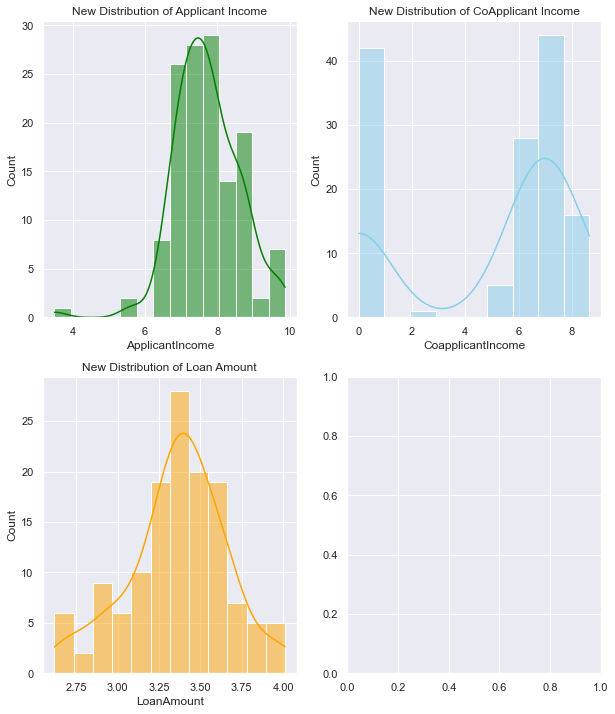

```python
sns.set(style="darkgrid")
fig, axs = plt.subplots(2, 2, figsize=(10, 12))

sns.histplot(data=df, x="ApplicantIncome", kde=True, ax=axs[0, 0], color='green').set(title = "New Distribution of Applicant Income");
sns.histplot(data=df, x="CoapplicantIncome", kde=True, ax=axs[0, 1], color='skyblue').set(title = "New Distribution of CoApplicant Income");
sns.histplot(data=df, x="LoanAmount", kde=True, ax=axs[1, 0], color='orange').set(title = "New Distribution of Loan Amount");
```

Features Separating - Seperating Dependent and Independent Variables

```python
df
```

|  | ApplicantIncome | CoapplicantIncome | LoanAmount | Loan_Amount_Term | Credit_History | Gender | Married | Dependents_0 | Dependents_1 | Dependents_2 | Dependents_3+ | Education | Self_Employed | Property_Area_Rural | Property_Area_Semiurban | Property_Area_Urban | Loan_Status |
| --- | --- | --- | --- | --- | --- | --- | --- | --- | --- | --- | --- | --- | --- | --- | --- | --- | --- |
| 0 | 8.745213 | 0.000000 | 3.478518 | 360.0 | 1.0 | 1 | 0 | 1 | 0 | 0 | 0 | 1 | 0 | 0 | 0 | 1 | 1 |
| 4 | 8.801117 | 0.000000 | 3.445917 | 360.0 | 1.0 | 1 | 0 | 1 | 0 | 0 | 0 | 1 | 0 | 0 | 0 | 1 | 1 |
| 13 | 6.560982 | 7.300113 | 3.267580 | 360.0 | 1.0 | 1 | 0 | 1 | 0 | 0 | 0 | 1 | 0 | 1 | 0 | 0 | 0 |
| 15 | 8.387862 | 0.000000 | 3.343702 | 360.0 | 1.0 | 1 | 0 | 1 | 0 | 0 | 0 | 1 | 0 | 0 | 0 | 1 | 1 |
| 19 | 7.140742 | 7.691606 | 3.274722 | 360.0 | 1.0 | 1 | 1 | 1 | 0 | 0 | 0 | 1 | 0 | 0 | 0 | 1 | 1 |
| ... | ... | ... | ... | ... | ... | ... | ... | ... | ... | ... | ... | ... | ... | ... | ... | ... | ... |
| 579 | 7.510607 | 7.349099 | 3.562103 | 360.0 | 1.0 | 1 | 0 | 1 | 0 | 0 | 0 | 1 | 0 | 0 | 0 | 1 | 1 |
| 586 | 6.922935 | 6.246024 | 3.193437 | 360.0 | 1.0 | 1 | 1 | 1 | 0 | 0 | 0 | 1 | 0 | 0 | 0 | 1 | 1 |
| 588 | 8.301822 | 0.000000 | 3.113737 | 360.0 | 1.0 | 1 | 0 | 1 | 0 | 0 | 0 | 1 | 0 | 0 | 1 | 0 | 1 |
| 603 | 7.786528 | 8.098272 | 3.621447 | 360.0 | 1.0 | 1 | 0 | 1 | 0 | 0 | 0 | 1 | 0 | 1 | 0 | 0 | 1 |
| 608 | 7.539939 | 6.645209 | 3.223710 | 360.0 | 1.0 | 1 | 1 | 1 | 0 | 0 | 0 | 1 | 0 | 1 | 0 | 0 | 1 |

136 rows × 17 columns

```python
X = df.drop(["Loan_Status"], axis=1)
y = df["Loan_Status"]
```

SMOTE Technique- Synthetic Minority Oversampling Technique

```python
X, y = SMOTE().fit_resample(X, y);
```

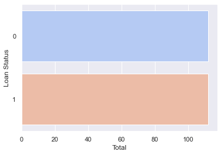

```python
#Representation that Distribution of Loan Status is Balanced
sns.set_theme(style="darkgrid")
sns.countplot(y=y, data=df, palette="coolwarm")
plt.ylabel('Loan Status')
plt.xlabel('Total')
plt.show()
```

Data Normalization

```python
X = MinMaxScaler().fit_transform(X)
```

```python
X
```

```
array([[0.82283215, 0.        , 0.61735797, ..., 0.        , 0.        ,
        1.        ],
       [0.83160138, 0.        , 0.5939598 , ..., 0.        , 0.        ,
        1.        ],
       [0.48020915, 0.84294445, 0.46596719, ..., 1.        , 0.        ,
        0.        ],
       ...,
       [0.56202244, 0.75843008, 0.66382937, ..., 1.        , 0.        ,
        0.        ],
       [0.79677239, 0.        , 0.4939637 , ..., 0.        , 0.        ,
        1.        ],
       [0.81111942, 0.87355258, 0.87295461, ..., 0.        , 0.        ,
        0.        ]])
```

Splitting the Data Set

```python
X_train, X_test, y_train, y_test = train_test_split(X, y, test_size = 0.2, random_state = 0)
```

ML Models

Logistic Regression- the dependent variable variable is a dichotomous variable (0,1). It tells the probability of true/false- tell if a variable is helping a prediction. Logistic regression can't use least squares- instead it uses maximum likelihood. Can be used to assess what variables are useful for a variable.

```python
LRclassifier = LogisticRegression(solver='saga', max_iter=500, random_state=1)
LRclassifier.fit(X_train, y_train)

y_pred = LRclassifier.predict(X_test)

print(classification_report(y_test, y_pred))
print(confusion_matrix(y_test, y_pred))

from sklearn.metrics import accuracy_score
LRAcc = accuracy_score(y_pred,y_test)
print('LR accuracy: {:.2f}%'.format(LRAcc*100))
```

```
              precision    recall  f1-score   support

           0       0.78      0.61      0.68        23
           1       0.67      0.82      0.73        22

    accuracy                           0.71        45
   macro avg       0.72      0.71      0.71        45
weighted avg       0.72      0.71      0.71        45

[[14  9]
 [ 4 18]]
LR accuracy: 71.11%
```